# Simulation demonstration of the `multAbund` package

Devin S. Johnson

2016-01-28

Here I present a realistic demonstration of the `multAbund` package for multivariate species distribution modeling.

## 1. Preliminaries

These are the packages necessary for the execution. In addition a seed is set for reproducability

```r
library(multAbund)
library(ggplot2)
library(cowplot)
library(ggdendro)
library(magrittr)
library(reshape2)
library(mvtnorm)
library(viridis)
```

## 2. Simulation Design and Models

Next we set up the design for the simulation. There are 20 species, 35 samples (of which 5 will be used for prediction), and 5 groups. In addition, I simulate 4 covariates `V1`,…,`V4`. The first 3 will be be used for clustering and the 4th (`V4`) will be an “effort” variable

```r
### Design
num_spec=20
num_obs=35
num_groups = 5
group_comp = round(num_spec*(c(num_groups:1)/sum(c(num_groups:1))))
env_dat = data.frame(obs=1:num_obs, V1=rnorm(num_obs), V2=rnorm(num_obs), V3=rnorm(num_obs), V4=rnorm(num_obs))
cnt_dat=data.frame(obs=rep(1:num_obs, each=num_spec), species=rep(1:num_spec, num_obs), count=NA)
cnt_dat = merge(cnt_dat, env_dat)
cnt_dat = with(cnt_dat, cnt_dat[order(species, obs), ])
```

```r
### Model
delta_model = ~V1+V2+V3
X_model = ~V1+V2+V3+V4
group = factor(rep(1:num_groups, group_comp))
data_mats = make_data_list(delta_model = delta_model, X_model = X_model, data=cnt_dat, sigma_model=~1)
C_pi = model.matrix(~group-1)
K_pi = kronecker(C_pi, data_mats$H)
X = data_mats$X
```

## 3. Simulation

Here the parameters and counts are simulated.

```r
### Parmeters
set.seed(1234)
omega = 1.25
Omega = omega^2*solve(crossprod(data_mats$H))
delta_pi = rmvnorm(num_groups, sigma=Omega)
delta_pi = as.vector(t(sweep(delta_pi, 2,  apply(delta_pi, 2, mean), "-")))
beta = c(2,1,0,-1,0.5)

z =  X%*%beta + K_pi%*%delta_pi
cnt_dat$count = rpois(n=length(z), exp(z))
```

## 4. The design matrix lists are created for the MCMC functions.

```r
data_mats = make_data_list(counts="count", delta_model = delta_model,
                           X_model = X_model, data=cnt_dat,
                           sigma_model=~1)
pred_mats = make_data_list(counts="count", delta_model = delta_model,
                           X_model = X_model, data=cnt_dat,
                           sigma_model=~1)
```

## 5. Prior paramters and initial values

Here we define the prior distribution parameters and initial values. To find the initial values, we will assume that all species belong to there own group, i.e., there are `num_species` groups.

```r
fit0 = glm(count ~ 1, data=cnt_dat, family="poisson")

#target0=function(n){return(rep(1/n, n))}
alpha_prior = get_opt_alpha_prior(
  num_spec#, target0
)

prior_parm = list(
  a_alpha=alpha_prior[[1]][1],
  b_alpha=alpha_prior[[1]][2],
  Sigma_beta_inv = crossprod(data_mats$X)/100,
  mu_beta = c(fit0$coefficients, rep(0,ncol(X)-1)),
  phi_omega = 1,
  df_omega = 1,
  phi_sigma = 1,
  df_sigma = 51
)

inits=list(
  beta = with(data_mats, solve(crossprod(X),crossprod(X, log(n+0.5)))),
  groups=c(1:20),
  delta = rep(0, ncol(data_mats$H)*num_spec),
  omega=1,
  sigma = rep(1.0E-4, ncol(data_mats$D)),
  log_alpha=0
)
```

## 6. Model fitting via MCMC

Here the model is fit via MCMC. Within the MCMC sampler, there is a mixture of Gibbs updates (i.e., full conditional distribution is a common distribution) and Metropolis-within-Gibbs (i.e., there is a proposal and accept/reject step). I used adaptive Metropolis proposals that are tuned every `block` iterations. In the following example, proposals are adjusted every `block=200` iterations.

```r
block=200
burn=10000
iter=50000

fit = mult_abund_pois(
  data_list=data_mats,
  pred_list = data_mats,
  initial_list = inits,
  prior_list = prior_parm,
  block = block,
  begin_group_update=5*block,
  burn = burn,
  iter = iter
)
```

## 7. Bayesian cluster and fit inference

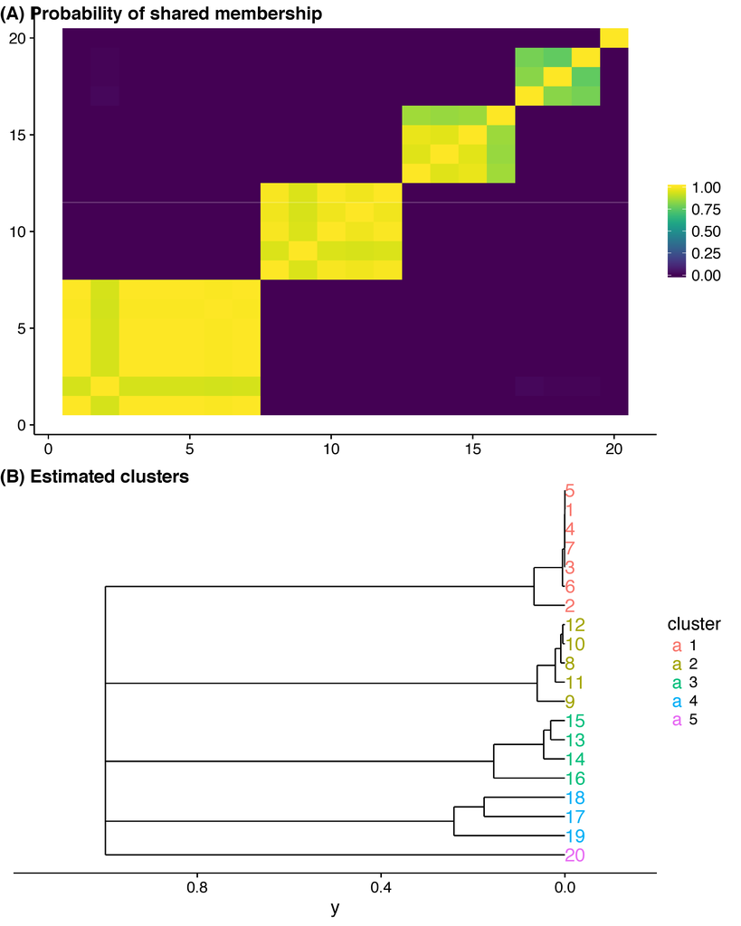

```r
# Posterior probability of shared group membership
p1 = ggplot(aes(x=Var1, y=Var2), data=melt(apply(fit$prox, c(1,2), mean))) + geom_tile(aes(fill=value)) + labs(x=NULL, y=NULL) +
  labs(x=NULL, y=NULL) + scale_fill_viridis("",limits=c(0, 1))

# Fitted clustering of species
kappa_dist = table(fit$kappa_pi)
kappa = as.numeric(names(kappa_dist)[kappa_dist==max(kappa_dist)])
d <- as.dist(1-apply(fit$prox, c(1,2), mean))
hc = hclust(d, method="complete")
dendr    <- dendro_data(hc, type="rectangle")
clust    <- cutree(hc,k=kappa)
clust.df <- data.frame(label=1:20, cluster=factor(clust))
dendr[["labels"]] <- merge(dendr[["labels"]],clust.df, by="label")
p2 = ggplot() +
  geom_segment(data=segment(dendr), aes(x=x, y=y, xend=xend, yend=yend)) +
  geom_text(data=label(dendr), aes(x, y, label=label, hjust=0, color=cluster), size=5) +
  coord_flip() + scale_y_reverse(expand=c(0.2, 0)) +
  theme(
    axis.line.y=element_blank(), axis.text.y=element_blank(),
    axis.ticks.y=element_blank()
  ) + xlab(NULL)
g1=plot_grid(p1, p2, labels = c("(A) Probability of shared membership", "(B) Estimated clusters"), hjust=0, ncol=1)
print(g1)
```

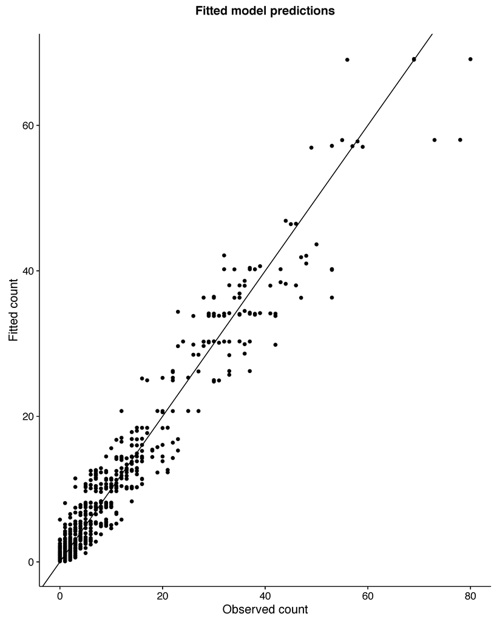

```r
# Fit and prediction
fit_data = data.frame(count=cnt_dat$count, fit=apply(fit$pred, 2, mean))
p4=ggplot(aes(x=count, y=fit), data=fit_data) + geom_point() + geom_abline(intercept=0,slope=1) +
  xlab("Observed count") + ylab("Fitted count") + ggtitle("Fitted model predictions\n")
print(p4)
```